## Лабораторна робота №9

# Ймовірнісний аналіз неперервних випадкових величин з використанням Numpy і SciPy

Далі наведено завдання до лабораторної роботи і приклади їх виконання для розподілу Гаусса. Кожний студент має окреме завдання відповідно до [варіанту](https://dl.tntu.edu.ua/mods/_core/file_manager/preview.php?file=CH21_2020.pdf&pathext=&popup=0). Для кожного варіанту задано [назву розподілу, його параметри та відповідне посилання на документацію](https://dl.tntu.edu.ua/mods/_core/file_manager/preview.php?file=task-l9.pdf&pathext=&popup=0) модуля [scipy.stats](https://docs.scipy.org/doc/scipy/reference/stats.html).

### Завдання 1.

Записати вираз щільності заданого розподілу (представити у звіті), відповідно до варіанту. Охарактеризувати область його практичного застосування (кілька речень).

### Завдання 2.

Зобразити графіки щільності розподілу та функції розподілу.

#### Приклад

(розподіл Гаусса (нормальний розподіл) з математичним сподіванням a = 3, середнім квадратичним відхиленням sigma = 5)

```python
import numpy as np

from scipy.stats import norm
# тут потрібно імпортувати модуль, що стосується того розподілу, що у завданні відповідно до варіанту

import matplotlib.pyplot as plt
```

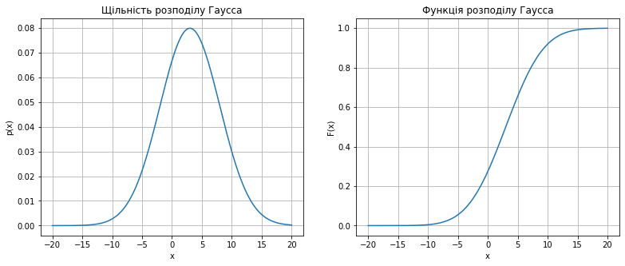

```python
# задаємо масив точок на осі x (тут 10000 точок в інтервалі від -20 до 20)
x = np.linspace(-20, 20, 10000)

#параметри розподілу, відповідно до варіанту
a = 3
sigma = 5

# масив значень щільності розподілу
p = norm.pdf(x, a, sigma)

# масив значень функції розподілу
F = norm.cdf(x, a, sigma)


# побудова графіків з використанням matplotlib (object-oriented API)
fig, ax = plt.subplots(1, 2, figsize=(13, 5))

ax[0].plot(x, p)
ax[1].plot(x, F)

ax[0].grid()
ax[1].grid()

ax[0].set(xlabel='x', ylabel='p(x)',
       title='Щільність розподілу Гаусса')

ax[1].set(xlabel='x', ylabel='F(x)',
       title='Функція розподілу Гаусса')

plt.show()
```

### Завдання 3.

Обчислити математичне сподівання, дисперсію, коефіцієнти асиметрії та ексцесу

#### Приклад

```python
m, var, skew, kurt = norm.stats(a, sigma, moments='mvsk')

print(f' Математичне сподівання = {m:.3f}, дисперсія = {var:.3f} \n',
        f'Коефіцієнт асиметрії = {skew:.3f}, коефіцієнт ексцесу = {kurt:.3f}')
```

```
 Математичне сподівання = 3.000, дисперсія = 25.000
 Коефіцієнт асиметрії = 0.000, коефіцієнт ексцесу = 0.000
```

### Завдання 4.

Обчислити квантиль рівня $V\over40$ (де $V$ - номер варіанту), медіану розподілу

#### Приклад

```python
# квантиль рівня 0.3
kv_03 = norm.ppf(0.3, a, sigma)

# медіана
med = norm.median(a, sigma)

print(f'Квантиль рівня 0.3 дорівнює {kv_03:.3f}, медіана дорівнює {med:.3f}')
```

```
Квантиль рівня 0.3 дорівнює 0.378, медіана дорівнює 3.000
```

### Завдання 5.

Знайти ймовірність попадання випадкової величини у інтервал [-t1, t2], де t1 = V/20, t2 = V/30

#### Приклад

```python
# ймовірність попадання в інтервал [-0.5, 0.6]
P = norm.cdf(0.6, a, sigma) - norm.cdf(-0.5, a, sigma)

print(f'Ймовірність попадання випадкової величини у інтервал [-0.5, 0.6] дорівнює {P:.5f}')
```

```
Ймовірність попадання випадкової величини у інтервал [-0.5, 0.6] дорівнює 0.07365
```

### Завдання 6. Комп'ютерне імітаційне моделювання випадкових величин із заданим розподілом.

Згенерувати 1000 псевдовипадкових чисел із заданим розподілом, зобразити їх графічно

#### Приклад

```
[ 2.41506165  4.13413411 -4.82034181  0.0233282  16.88508675 12.65819098
 -1.54849412  7.85872463  5.45860762 -5.13362683]
```

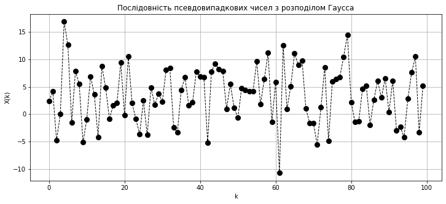

```python
n = 1000

# формування масиву псевдовипадкових чисел із розподілом Гаусса з використанням scipy.stats
X = norm.rvs(a, sigma, size=n)

# перші 10 елементів
print(X[0:10])


# графічне зображення згенерованої послідовності (перших 100 її елементів), pyplot API

plt.figure(figsize=(12,5))
plt.plot(X[0:100], 'ko--', linewidth=1, markersize=8)

plt.title('Послідовність псевдовипадкових чисел з розподілом Гаусса')
plt.xlabel('k')
plt.ylabel('X(k)')

plt.grid()
plt.show()
```

### Завдання 7. Обчислення кількості елементів масиву, що задовольняють певній умові. Bar Chart. Pie Chart

Розбити область можливих значень випадкової величини на 3 підінтервали (довільно). Обчислити кількість псевдовипадкових чисел, що попадають у кожен iнтервал. Візуалізувати отриманий результат з використанням Bar Chart і Pie Chart

#### Приклад

Область значень гауссівської випадкової величини $(-\infty, \infty)$. Розглянемо її розбиття на три підінтервали:  
$(-\infty, -0.01],$  
$(-0.01, 1.3),$  
$[1.3, \infty)$

```python
# Масив елементів, які попадають у перший інтервал
X1 = X[X <= -0.01]

# Масив елементів, які попадають у другий інтервал
X2 = X[(X > -0.01) & (X < 1.3)]

# Масив елементів, які попадають у третій інтервал
X3 = X[X >= 1.3]

# Число елементів у кожному масиві
Y = [len(X1), len(X2), len(X3)]

print(Y)
```

```
[270, 103, 627]
```

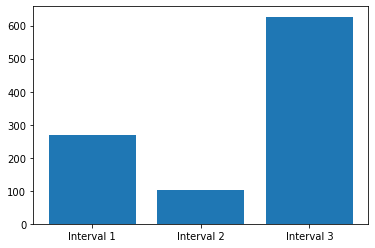

```python
# Bar Chart

objects = ('Interval 1', 'Interval 2', 'Interval 3')

plt.bar(objects, Y)

plt.show()
```

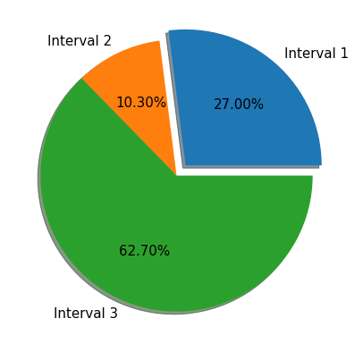

```python
# Pie Chart

plt.figure(figsize=(7,7))

plt.pie(Y, labels = objects, explode=[0.1, 0, 0], autopct='%.2f%%', shadow=True, textprops = {"fontsize":15})

plt.show()
```